# pres_T3.4_salida_estacionaria slides

## Análisis de Salida: Estado Estacionario

### T3.4 · Modelado de Sistemas bajo Incertidumbre

Universidad de los Andes · Ingeniería Industrial

## Agenda

1. Problema del período transitorio (warm-up)
2. Método de Welch — determinación gráfica de t_w
3. **Ejemplo 1:** M/M/1 estacionario con Batch Means + Von Neumann
4. Common Random Numbers (CRN) — reducción de varianza
5. **Ejemplo 2:** M/M/1 vs M/D/1 con CRN — prueba pareada y eficiencia
6. **Ejemplo 3:** call center 6 vs 7 agentes — selección con CRN
7. Resumen del Módulo 3

## El problema del warm-up

Toda simulación arranca desde un estado inicial X(0) que no es representativo del estado estacionario. Las observaciones del **período transitorio** sesgan la estimación.

$$E\left[\bar{Y}_m\right] = \theta + \underbrace{\frac{1}{m}\sum_{i=1}^{m}(E[Y_i] - \theta)}_{\text{sesgo de inicialización}}$$

El sesgo **no desaparece** al aumentar réplicas. Solo se elimina descartando el transitorio.

**Método de Welch:** promediar entre réplicas → suavizar con media móvil → identificar estabilización visual.

## Batch Means

Una corrida larga (post warm-up) se divide en m lotes de b observaciones. Las medias de lote Ȳ₁,...,Ȳₘ se tratan como i.i.d. si b es suficientemente grande.

$$IC = \bar{Y}_m \pm t_{\alpha/2,\, m-1} \cdot \frac{S_B}{\sqrt{m}}$$

**Verificación de independencia (Von Neumann):** $$VN = \frac{\sum(\bar{Y}_{j+1} - \bar{Y}_j)^2}{(m-1) \cdot S_B^2} \approx 2 \text{ bajo independencia}$$

Si VN << 2, los lotes están correlacionados → aumentar b.

## Ejemplo 1 — M/M/1 estacionario con Batch Means

Línea de producción 24/7: λ=4 pzas/min, μ=5 pzas/min, ρ=0.8. Una corrida larga de 50,000 clientes. Descartar warm-up, dividir en lotes.

**Referencia analítica:** $W_q = \rho/[\mu(1-\rho)] = 0.80$ min

**Plan:**

1. Método de Welch → determinar t_w
2. Batch Means → IC para Wq
3. Verificar independencia de lotes (Von Neumann + ACF)

```python
import simpy
import numpy as np
import matplotlib.pyplot as plt
from scipy import stats as st

def mm1_largo(lam, mu, n_clientes, seed):
    """Simula M/M/1 hasta atender n_clientes y retorna el vector de esperas."""
    np.random.seed(seed)
    esperas = []

    def cliente(env, srv):
        t_arr = env.now
        with srv.request() as req:
            yield req
            esperas.append(env.now - t_arr)
            yield env.timeout(np.random.exponential(1/mu))

    def llegadas(env, srv):
        i = 0
        while i < n_clientes:
            yield env.timeout(np.random.exponential(1/lam))
            env.process(cliente(env, srv))
            i += 1

    env = simpy.Environment()
    srv = simpy.Resource(env, capacity=1)
    env.process(llegadas(env, srv))
    env.run()
    return np.array(esperas)

print('Función mm1_largo definida.')
```

```
Función mm1_largo definida.
```

```python
lam, mu = 4, 5
Wq_ref = (lam/mu) / (mu * (1-lam/mu))

k_welch = 10
n_welch = 10000
print(f'Ejecutando {k_welch} réplicas de {n_welch} clientes para el método de Welch…')
replicas_welch = [mm1_largo(lam, mu, n_welch, seed=100+j) for j in range(k_welch)]
min_len = min(len(r) for r in replicas_welch)
Y_bar_i = np.mean([r[:min_len] for r in replicas_welch], axis=0)
print(f'Listo. Cada vector tiene {min_len} observaciones.')
```

```
Ejecutando 10 réplicas de 10000 clientes para el método de Welch…
```

```
Listo. Cada vector tiene 10000 observaciones.
```

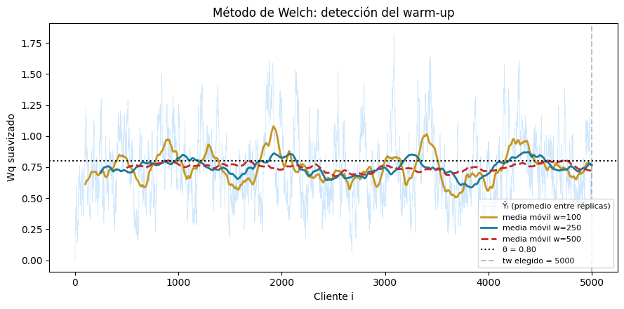

```python
fig, ax = plt.subplots(figsize=(9, 4.5))
ax.plot(Y_bar_i[:5000], color='#BBDEFB', lw=0.5, alpha=0.7, label='Ȳᵢ (promedio entre réplicas)')
for w, col, ls in [(100, '#C8961E', '-'), (250, '#1A7A9A', '-'), (500, '#C62828', '--')]:
    smoothed = np.convolve(Y_bar_i, np.ones(2*w+1)/(2*w+1), mode='valid')
    ax.plot(range(w, w+len(smoothed))[:5000-w], smoothed[:5000-w],
            color=col, lw=2, ls=ls, label=f'media móvil w={w}')
ax.axhline(Wq_ref, ls=':', color='black', lw=1.5, label=f'θ = {Wq_ref:.2f}')
ax.axvline(5000, ls='--', color='gray', alpha=0.5, label='tw elegido = 5000')
ax.set_xlabel('Cliente i'); ax.set_ylabel('Wq suavizado')
ax.set_title('Método de Welch: detección del warm-up')
ax.legend(fontsize=8, loc='lower right')
plt.tight_layout(); plt.show()
```

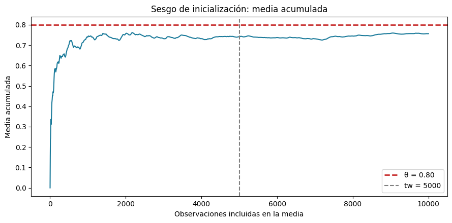

```
Warm-up elegido: tw = 5000 clientes (conservador)
```

```python
media_acum = np.cumsum(Y_bar_i) / np.arange(1, len(Y_bar_i)+1)

fig, ax = plt.subplots(figsize=(9, 4.5))
ax.plot(media_acum, color='#1A7A9A', lw=1.5)
ax.axhline(Wq_ref, ls='--', color='#C62828', lw=2, label=f'θ = {Wq_ref:.2f}')
ax.axvline(5000, ls='--', color='gray', label='tw = 5000')
ax.set_xlabel('Observaciones incluidas en la media'); ax.set_ylabel('Media acumulada')
ax.set_title('Sesgo de inicialización: media acumulada')
ax.legend()
plt.tight_layout(); plt.show()
print(f'Warm-up elegido: tw = 5000 clientes (conservador)')
```

```python
W_largo = mm1_largo(lam, mu, 50000, seed=42)

tw = 5000
W_post = W_largo[tw:]
n_obs = len(W_post)
m_lotes = 30
b_tam = n_obs // m_lotes

Y_batch = np.array([W_post[j*b_tam:(j+1)*b_tam].mean() for j in range(m_lotes)])

Ybar_B = Y_batch.mean()
SB = Y_batch.std(ddof=1)
t_c = st.t.ppf(0.975, m_lotes-1)
h_B = t_c * SB / np.sqrt(m_lotes)
VN = np.sum(np.diff(Y_batch)**2) / ((m_lotes-1) * SB**2)
T_val = (Ybar_B - Wq_ref) / (SB/np.sqrt(m_lotes))
p_val = 2*(1 - st.t.cdf(abs(T_val), m_lotes-1))

print(f'═══ BATCH MEANS ═══')
print(f'Observaciones totales: {len(W_largo)}')
print(f'Warm-up descartado:    {tw}')
print(f'Observaciones usadas:  {n_obs}')
print(f'Lotes:    m = {m_lotes},  tamaño b = {b_tam}')
print(f'\nȲ      = {Ybar_B:.4f} min')
print(f'SB     = {SB:.4f} min')
print(f'IC 95% = [{Ybar_B-h_B:.4f}, {Ybar_B+h_B:.4f}]')
print(f'\nRef. analítica  Wq = {Wq_ref:.4f}')
print(f'¿IC contiene la referencia? {"Sí ✓" if Ybar_B-h_B <= Wq_ref <= Ybar_B+h_B else "No"}')
print(f'Error relativo: {abs(Ybar_B-Wq_ref)/Wq_ref*100:.1f}%')
print(f'Prueba t:  T = {T_val:+.3f},  p-valor = {p_val:.3f}')
print(f'\nVon Neumann:  VN = {VN:.2f}  (≈2 bajo independencia)  {"✓" if 1.5 < VN < 2.5 else "⚠️"}')
```

```
═══ BATCH MEANS ═══
Observaciones totales: 50000
Warm-up descartado:    5000
Observaciones usadas:  45000
Lotes:    m = 30,  tamaño b = 1500

Ȳ      = 0.7790 min
SB     = 0.2092 min
IC 95% = [0.7008, 0.8571]

Ref. analítica  Wq = 0.8000
¿IC contiene la referencia? Sí ✓
Error relativo: 2.6%
Prueba t:  T = -0.550,  p-valor = 0.586

Von Neumann:  VN = 1.88  (≈2 bajo independencia)  ✓
```

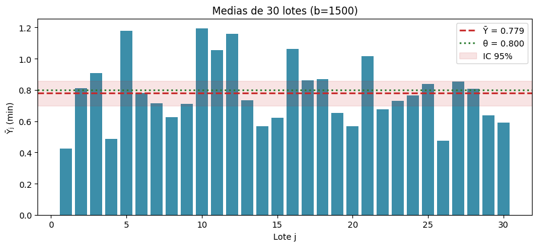

```python
fig, ax = plt.subplots(figsize=(9, 4.2))
ax.bar(range(1, m_lotes+1), Y_batch, color='#1A7A9A', alpha=0.85)
ax.axhline(Ybar_B, color='#C62828', lw=2, ls='--', label=f'Ȳ = {Ybar_B:.3f}')
ax.axhline(Wq_ref, color='#2E7D32', lw=2, ls=':', label=f'θ = {Wq_ref:.3f}')
ax.axhspan(Ybar_B-h_B, Ybar_B+h_B, alpha=0.12, color='#C62828', label='IC 95%')
ax.set_xlabel('Lote j'); ax.set_ylabel('Ȳⱼ (min)')
ax.set_title(f'Medias de {m_lotes} lotes (b={b_tam})')
ax.legend()
plt.tight_layout(); plt.show()
```

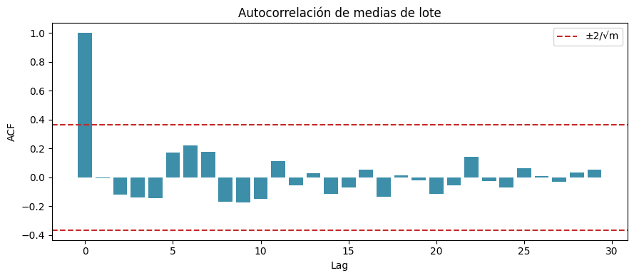

```python
y_c = Y_batch - Y_batch.mean()
acf_batch = np.correlate(y_c, y_c, 'full')
acf_batch = acf_batch[len(acf_batch)//2:] / acf_batch[len(acf_batch)//2]

fig, ax = plt.subplots(figsize=(9, 4))
ax.bar(range(len(acf_batch)), acf_batch, color='#1A7A9A', alpha=0.85)
ax.axhline(2/np.sqrt(m_lotes), ls='--', color='#C62828', label='±2/√m')
ax.axhline(-2/np.sqrt(m_lotes), ls='--', color='#C62828')
ax.set_xlabel('Lag'); ax.set_ylabel('ACF')
ax.set_title('Autocorrelación de medias de lote')
ax.legend()
plt.tight_layout(); plt.show()
```

## Common Random Numbers (CRN)

Para comparar dos sistemas, usar la **misma** secuencia aleatoria en ambos. Esto introduce correlación positiva y reduce Var[Δ].

$$\text{Var}[\Delta_j] = \text{Var}[Y_j^{(1)}] + \text{Var}[Y_j^{(2)}] - 2\,\text{Cov}(Y_j^{(1)}, Y_j^{(2)})$$

Con CRN: Cov > 0 → Var[Δ] se reduce → IC más estrecho → menos réplicas necesarias.

⚠️ CRN requiere **sincronización correcta**: el mismo número aleatorio debe usarse para el mismo tipo de evento en ambos sistemas.

## Ejemplo 2 — M/M/1 vs M/D/1 con CRN

Misma carga (λ=4, μ=5, ρ=0.8), diferente variabilidad de servicio:

- **Sistema A:** servicio exponencial (CV=1) → Wq = 0.80 min
- **Sistema B:** servicio determinista (CV=0) → Wq = 0.40 min

El servicio determinista reduce Wq exactamente a la mitad.

```python
def mm1_vs_md1_crn(lam, mu, n_clientes, seed, warmup=1000):
    """M/M/1 y M/D/1 con CRN: misma secuencia de llegadas y mismos U_i."""
    np.random.seed(seed)
    inter_arrivals = np.random.exponential(1/lam, n_clientes)
    services_exp = np.random.exponential(1/mu, n_clientes)
    service_det = 1/mu

    def sim_queue(services, det=False):
        esperas = np.zeros(n_clientes)
        t_arr, t_sal = 0.0, 0.0
        for i in range(n_clientes):
            t_arr += inter_arrivals[i]
            w = max(0.0, t_sal - t_arr)
            esperas[i] = w
            s = service_det if det else services[i]
            t_sal = t_arr + w + s
        return esperas[warmup:].mean()

    return sim_queue(services_exp), sim_queue(None, det=True)


def mm1_vs_md1_indep(lam, mu, n_clientes, seed_A, seed_B, warmup=1000):
    """M/M/1 y M/D/1 con semillas independientes (sin CRN)."""
    def run(ia, sv, det=False):
        esperas = np.zeros(n_clientes)
        t_arr, t_sal = 0.0, 0.0
        for i in range(n_clientes):
            t_arr += ia[i]
            w = max(0.0, t_sal - t_arr)
            esperas[i] = w
            s = (1/mu) if det else sv[i]
            t_sal = t_arr + w + s
        return esperas[warmup:].mean()

    np.random.seed(seed_A)
    ia_A = np.random.exponential(1/lam, n_clientes)
    sv_A = np.random.exponential(1/mu, n_clientes)
    np.random.seed(seed_B)
    ia_B = np.random.exponential(1/lam, n_clientes)
    return run(ia_A, sv_A), run(ia_B, None, det=True)

print('Funciones CRN/independientes definidas.')
```

```
Funciones CRN/independientes definidas.
```

```python
n_rep = 30
n_cli = 6000

results_crn = np.array([mm1_vs_md1_crn(lam, mu, n_cli, seed=2000+j) for j in range(n_rep)])
Wq_A_crn, Wq_B_crn = results_crn[:, 0], results_crn[:, 1]
Delta_crn = Wq_A_crn - Wq_B_crn

results_indep = np.array([mm1_vs_md1_indep(lam, mu, n_cli, 3000+j, 4000+j) for j in range(n_rep)])
Delta_indep = results_indep[:, 0] - results_indep[:, 1]

print(f'═══ DIFERENCIA Δ = Wq(M/M/1) − Wq(M/D/1)  (n={n_rep}) ═══')
t_c30 = st.t.ppf(0.975, n_rep-1)
for nombre, delta in [('CRN', Delta_crn), ('Independientes', Delta_indep)]:
    m_d, s_d = delta.mean(), delta.std(ddof=1)
    h_d = t_c30 * s_d / np.sqrt(n_rep)
    print(f'\n--- {nombre} ---')
    print(f'  Δ̄  = {m_d:.4f} min,  S_Δ = {s_d:.4f}')
    print(f'  IC 95% = [{m_d-h_d:.4f}, {m_d+h_d:.4f}]')
    print(f'  Semiancho h = {h_d:.4f}')
```

```
═══ DIFERENCIA Δ = Wq(M/M/1) − Wq(M/D/1)  (n=30) ═══

--- CRN ---
  Δ̄  = 0.3679 min,  S_Δ = 0.0768
  IC 95% = [0.3393, 0.3966]
  Semiancho h = 0.0287

--- Independientes ---
  Δ̄  = 0.4075 min,  S_Δ = 0.1562
  IC 95% = [0.3492, 0.4658]
  Semiancho h = 0.0583
```

```python
m_d = Delta_crn.mean()
s_d = Delta_crn.std(ddof=1)
T_paired = m_d / (s_d/np.sqrt(n_rep))
p_paired = 2*(1 - st.t.cdf(abs(T_paired), n_rep-1))
d_cohen = m_d / Wq_A_crn.std(ddof=1)
corr = np.corrcoef(Wq_A_crn, Wq_B_crn)[0, 1]

print('═══ PRUEBA t PAREADA (CRN) ═══')
print(f'T = {T_paired:.3f},  p-valor = {p_paired:.3e}')
print(f'd Cohen ≈ {d_cohen:.2f}   (efecto grande)')
print(f'Decisión: {"diferencia significativa → M/D/1 más rápido" if p_paired < 0.05 else "sin diferencia"}')

print('\n═══ EFICIENCIA DE CRN ═══')
print(f'Correlación entre Wq(A) y Wq(B) (CRN): r = {corr:.3f}')
reduccion = 1 - Delta_crn.std()/Delta_indep.std()
print(f'Reducción de S_Δ frente a indep.: {reduccion*100:.0f}%')
n_equiv = int(np.ceil(n_rep * (Delta_indep.std()/Delta_crn.std())**2))
print(f'Para igual IC sin CRN se necesitarían {n_equiv} réplicas (vs {n_rep} con CRN)')
```

```
═══ PRUEBA t PAREADA (CRN) ═══
T = 26.235,  p-valor = 0.000e+00
d Cohen ≈ 3.86   (efecto grande)
Decisión: diferencia significativa → M/D/1 más rápido

═══ EFICIENCIA DE CRN ═══
Correlación entre Wq(A) y Wq(B) (CRN): r = 0.622
Reducción de S_Δ frente a indep.: 51%
Para igual IC sin CRN se necesitarían 124 réplicas (vs 30 con CRN)
```

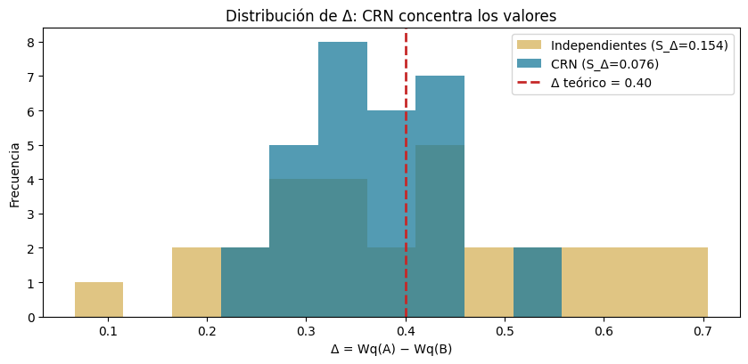

```python
fig, ax = plt.subplots(figsize=(8.5, 4.2))
bins = np.linspace(min(Delta_crn.min(), Delta_indep.min()),
                   max(Delta_crn.max(), Delta_indep.max()), 14)
ax.hist(Delta_indep, bins=bins, color='#C8961E', alpha=0.55,
        label=f'Independientes (S_Δ={Delta_indep.std():.3f})')
ax.hist(Delta_crn, bins=bins, color='#1A7A9A', alpha=0.75,
        label=f'CRN (S_Δ={Delta_crn.std():.3f})')
ax.axvline(0.40, color='#C62828', lw=2, ls='--', label='Δ teórico = 0.40')
ax.set_xlabel('Δ = Wq(A) − Wq(B)'); ax.set_ylabel('Frecuencia')
ax.set_title('Distribución de Δ: CRN concentra los valores')
ax.legend()
plt.tight_layout(); plt.show()
```

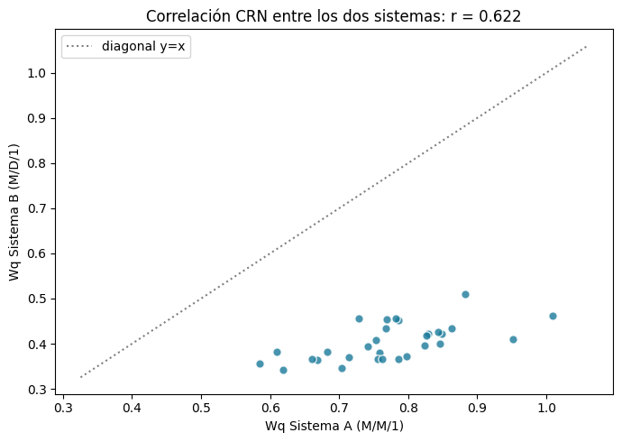

```python
fig, ax = plt.subplots(figsize=(7, 5))
ax.scatter(Wq_A_crn, Wq_B_crn, color='#1A7A9A', s=45, alpha=0.8, edgecolor='white')
lim = [min(Wq_A_crn.min(), Wq_B_crn.min())*0.95,
       max(Wq_A_crn.max(), Wq_B_crn.max())*1.05]
ax.plot(lim, lim, ls=':', color='gray', label='diagonal y=x')
ax.set_xlabel('Wq Sistema A (M/M/1)')
ax.set_ylabel('Wq Sistema B (M/D/1)')
ax.set_title(f'Correlación CRN entre los dos sistemas: r = {corr:.3f}')
ax.legend()
plt.tight_layout(); plt.show()
```

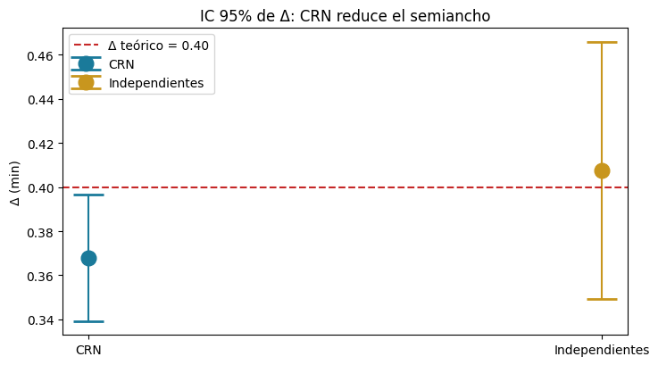

```python
fig, ax = plt.subplots(figsize=(7.5, 4.2))
labels = ['CRN', 'Independientes']
deltas = [Delta_crn, Delta_indep]
colors_ic = ['#1A7A9A', '#C8961E']
for i, (name, delta, col) in enumerate(zip(labels, deltas, colors_ic)):
    m_d_i = delta.mean()
    h_d_i = t_c30 * delta.std(ddof=1) / np.sqrt(n_rep)
    ax.errorbar(i, m_d_i, yerr=h_d_i, fmt='o', color=col,
                capsize=12, capthick=2, markersize=12, label=name)
ax.axhline(0.40, color='#C62828', ls='--', label='Δ teórico = 0.40')
ax.set_xticks([0, 1]); ax.set_xticklabels(labels)
ax.set_ylabel('Δ (min)')
ax.set_title('IC 95% de Δ: CRN reduce el semiancho')
ax.legend()
plt.tight_layout(); plt.show()
```

## Ejemplo 3 — Call center: 6 vs 7 agentes

**Decisión:** ¿el costo del 7º agente se justifica con la mejora?

```python
def call_center(lam_h, mu_L, sigma_L, c, T_h, seed, warmup_h=200):
    """Simula call center M/G/c con servicio Log-normal. Tiempos en min."""
    np.random.seed(seed)
    esperas = []
    T_min = T_h * 60
    warmup_min = warmup_h * 60
    lam_min = lam_h / 60

    def cliente(env, srv):
        t_arr = env.now
        with srv.request() as req:
            yield req
            w = env.now - t_arr
            if env.now > warmup_min:
                esperas.append(w)
            yield env.timeout(np.random.lognormal(mu_L, sigma_L))

    def llegadas(env, srv):
        while True:
            yield env.timeout(np.random.exponential(1/lam_min))
            env.process(cliente(env, srv))

    env = simpy.Environment()
    srv = simpy.Resource(env, capacity=c)
    env.process(llegadas(env, srv))
    env.run(until=T_min)

    if not esperas:
        return 0.0, 0.0
    return float(np.mean(esperas)), float(np.mean([w > 2 for w in esperas]))

print('Función call_center definida.')
```

```
Función call_center definida.
```

```python
mu_L, sigma_L = 1.7, 0.6
lam_call = 45
T_sim = 800
n_rep_cc = 30

print(f'Ejecutando {n_rep_cc} réplicas pareadas (CRN)…')
res_6, res_7 = [], []
for j in range(n_rep_cc):
    seed_j = 5000 + j
    res_6.append(call_center(lam_call, mu_L, sigma_L, c=6, T_h=T_sim, seed=seed_j))
    res_7.append(call_center(lam_call, mu_L, sigma_L, c=7, T_h=T_sim, seed=seed_j))

res_6 = np.array(res_6)
res_7 = np.array(res_7)
print(f'Listo. {n_rep_cc} pares de réplicas.')
```

```
Ejecutando 30 réplicas pareadas (CRN)…
```

```
Listo. 30 pares de réplicas.
```

```python
print(f'═══ RESULTADOS POR ALTERNATIVA (n={n_rep_cc}) ═══')
print(f'{"":<14} {"c=6":>22} {"c=7":>22}')
print('-'*60)
metric_names = ['Wq (min)', 'P(Wq>2 min)']
t_cN = st.t.ppf(0.975, n_rep_cc-1)
for i, name in enumerate(metric_names):
    m6, s6 = res_6[:,i].mean(), res_6[:,i].std(ddof=1)
    h6 = t_cN * s6/np.sqrt(n_rep_cc)
    m7, s7 = res_7[:,i].mean(), res_7[:,i].std(ddof=1)
    h7 = t_cN * s7/np.sqrt(n_rep_cc)
    print(f'{name:<14} {m6:>9.3f} ± {h6:<10.3f} {m7:>9.3f} ± {h7:<10.3f}')
```

```
═══ RESULTADOS POR ALTERNATIVA (n=30) ═══
                                  c=6                    c=7
------------------------------------------------------------
Wq (min)           2.399 ± 0.089          0.705 ± 0.021
P(Wq>2 min)        0.358 ± 0.007          0.133 ± 0.004
```

```python
print('═══ COMPARACIÓN PAREADA c=6 vs c=7 (CRN) ═══')
print('Corrección Bonferroni: con 2 pruebas, α* = 0.025')
print(f'{"Métrica":<14} {"D̄":>9} {"IC 95%(D)":>22} {"p":>10} {"Decisión":>14}')
print('-'*72)

decisiones = []
for i, name in enumerate(metric_names):
    D = res_6[:,i] - res_7[:,i]
    mD, sD = D.mean(), D.std(ddof=1)
    hD = t_cN * sD/np.sqrt(n_rep_cc)
    T = mD / (sD/np.sqrt(n_rep_cc)) if sD > 0 else float('inf')
    p = 2*(1-st.t.cdf(abs(T), n_rep_cc-1)) if sD > 0 else 0.0
    sig = p < 0.025
    decisiones.append((name, mD, hD, p, sig))
    print(f'{name:<14} {mD:>9.3f} [{mD-hD:>7.3f}, {mD+hD:>7.3f}] {p:>10.2e} {"sig.✓" if sig else "NS":>14}')

mD_wq = decisiones[0][1]
d_cohen = mD_wq / res_6[:,0].std(ddof=1)
print(f'\nTamaño de efecto (Wq): d Cohen ≈ {d_cohen:.2f}')

print('\n--- Decisión global ---')
n_sig = sum(1 for _,_,_,_,s in decisiones if s)
if n_sig >= 1 and decisiones[0][1] > 0:
    print(f'C=7 reduce Wq en ~{mD_wq:.2f} min y P(Wq>2) en {decisiones[1][1]*100:.1f} pp.')
    print('⇒ Recomendación: contratar el séptimo agente si el costo lo permite.')
else:
    print('⇒ Las dos configuraciones no se diferencian: mantener c=6.')
```

```
═══ COMPARACIÓN PAREADA c=6 vs c=7 (CRN) ═══
Corrección Bonferroni: con 2 pruebas, α* = 0.025
Métrica               D̄              IC 95%(D)          p       Decisión
------------------------------------------------------------------------
Wq (min)           1.694 [  1.608,   1.780]   0.00e+00          sig.✓
P(Wq>2 min)        0.225 [  0.218,   0.232]   0.00e+00          sig.✓

Tamaño de efecto (Wq): d Cohen ≈ 7.10

--- Decisión global ---
C=7 reduce Wq en ~1.69 min y P(Wq>2) en 22.5 pp.
⇒ Recomendación: contratar el séptimo agente si el costo lo permite.
```

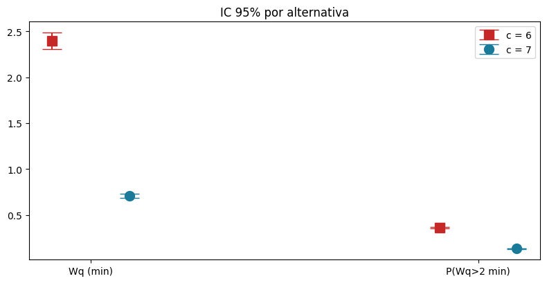

```python
fig, ax = plt.subplots(figsize=(8, 4.2))
x = np.arange(len(metric_names))
m6v = [res_6[:,i].mean() for i in range(2)]
m7v = [res_7[:,i].mean() for i in range(2)]
h6v = [t_cN*res_6[:,i].std(ddof=1)/np.sqrt(n_rep_cc) for i in range(2)]
h7v = [t_cN*res_7[:,i].std(ddof=1)/np.sqrt(n_rep_cc) for i in range(2)]
ax.errorbar(x-0.1, m6v, yerr=h6v, fmt='s', color='#C62828', capsize=10, markersize=10, label='c = 6')
ax.errorbar(x+0.1, m7v, yerr=h7v, fmt='o', color='#1A7A9A', capsize=10, markersize=10, label='c = 7')
ax.set_xticks(x); ax.set_xticklabels(metric_names)
ax.set_title('IC 95% por alternativa')
ax.legend()
plt.tight_layout(); plt.show()
```

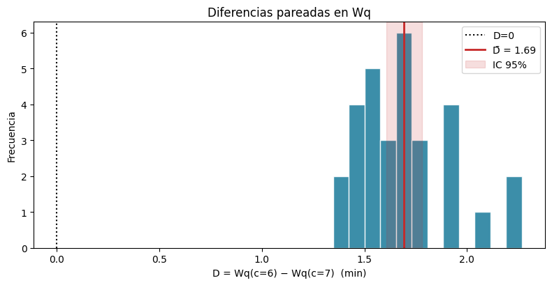

```python
D_Wq = res_6[:,0] - res_7[:,0]
mD = D_Wq.mean()
hD = t_cN * D_Wq.std(ddof=1) / np.sqrt(n_rep_cc)

fig, ax = plt.subplots(figsize=(8, 4.2))
ax.hist(D_Wq, bins=12, color='#1A7A9A', edgecolor='white', alpha=0.85)
ax.axvline(0, color='black', lw=1.5, ls=':', label='D=0')
ax.axvline(mD, color='#C62828', lw=2, label=f'D̄ = {mD:.2f}')
ax.axvspan(mD-hD, mD+hD, alpha=0.15, color='#C62828', label='IC 95%')
ax.set_xlabel('D = Wq(c=6) − Wq(c=7)  (min)'); ax.set_ylabel('Frecuencia')
ax.set_title('Diferencias pareadas en Wq')
ax.legend()
plt.tight_layout(); plt.show()
```

## Conclusiones — Módulo 3

- El **warm-up** debe descartarse explícitamente; el método de Welch lo identifica gráficamente.
- **Batch Means** estima IC para sistemas estacionarios; la **razón de Von Neumann** valida la independencia entre lotes.
- **Common Random Numbers** reduce drásticamente la varianza de Δ y permite decidir entre alternativas con menos réplicas.
- La **prueba t pareada** acompaña al IC: cuantifica la evidencia con un p-valor y un tamaño de efecto.
- Para múltiples métricas, aplicar **Bonferroni** o un equivalente para no inflar el error tipo I.
- En ausencia de fórmulas (M/G/c con LogNormal, prioridades, redes) la simulación es la única vía.

**Cierre del Módulo 3:** entradas (T3.1) → V&V (T3.2) → salida terminal (T3.3) → salida estacionaria (T3.4).